# WhiteWine

```r
# Install and load all packages up-front!
#pkgs <- c("cluster",  "NbClust")
mirrorUrl = "http://cran.ma.imperial.ac.uk"

# read xl
if(!require(readxl)) install.packages("readxl",repos = mirrorUrl)
if(!require(cluster)) install.packages("cluster",repos = mirrorUrl)
if(!require(NbClust)) install.packages("NbClust",repos = mirrorUrl)
#install.packages("readxl")
library("readxl")

#install.packages(pkgs)
#library(NbClust)
#getwd()
#myWD = "C:/Users/Lenovo/Documents/R/R-Markdown"
#setwd(myWD)
#knitr::opts_knit$set(root.dir = myWD)
#getwd()
```

# Question 1: White Wine clustering

## Starting off

> You need to conduct the k-means clustering analysis of the white wine sheet. Find the ideal number of clusters (please justify your answer). Choose the best two possible numbers of clusters and perform the k-means algorithm for both candidates. Validate which clustering test is more accurate. For the winning test, get the mean of the each attribute of each group. Before conducting the k-means, please investigate if you need to add in your code any pre-processing task (justify your answer). Write a code in R Studio to address all the above issues. In your report, check the consistency of those produced clusters, with information obtained from column 12.

Firstly we need to load the data…

```r
#going to import the Excel spreadsheet WhiteWine dataset
# xlsx files
wine.raw <- read_excel("../data/Whitewine.xlsx")
head(wine.raw)
```

```
## # A tibble: 6 x 12
##   `fixed acidity` `volatile acidity` `citric acid` `residual sugar`
##             <dbl>              <dbl>         <dbl>            <dbl>
## 1             7.0               0.27          0.36             20.7
## 2             6.3               0.30          0.34              1.6
## 3             8.1               0.28          0.40              6.9
## 4             7.2               0.23          0.32              8.5
## 5             7.2               0.23          0.32              8.5
## 6             8.1               0.28          0.40              6.9
## # ... with 8 more variables: chlorides <dbl>, `free sulfur dioxide` <dbl>,
## #   `total sulfur dioxide` <dbl>, density <dbl>, pH <dbl>,
## #   sulphates <dbl>, alcohol <dbl>, quality <dbl>
```

Here’s a a glance at the datset

```r
str(wine.raw)
```

```
## Classes 'tbl_df', 'tbl' and 'data.frame':    4898 obs. of  12 variables:
##  $ fixed acidity       : num  7 6.3 8.1 7.2 7.2 8.1 6.2 7 6.3 8.1 ...
##  $ volatile acidity    : num  0.27 0.3 0.28 0.23 0.23 0.28 0.32 0.27 0.3 0.22 ...
##  $ citric acid         : num  0.36 0.34 0.4 0.32 0.32 0.4 0.16 0.36 0.34 0.43 ...
##  $ residual sugar      : num  20.7 1.6 6.9 8.5 8.5 6.9 7 20.7 1.6 1.5 ...
##  $ chlorides           : num  0.045 0.049 0.05 0.058 0.058 0.05 0.045 0.045 0.049 0.044 ...
##  $ free sulfur dioxide : num  45 14 30 47 47 30 30 45 14 28 ...
##  $ total sulfur dioxide: num  170 132 97 186 186 97 136 170 132 129 ...
##  $ density             : num  1.001 0.994 0.995 0.996 0.996 ...
##  $ pH                  : num  3 3.3 3.26 3.19 3.19 3.26 3.18 3 3.3 3.22 ...
##  $ sulphates           : num  0.45 0.49 0.44 0.4 0.4 0.44 0.47 0.45 0.49 0.45 ...
##  $ alcohol             : num  8.8 9.5 10.1 9.9 9.9 10.1 9.6 8.8 9.5 11 ...
##  $ quality             : num  6 6 6 6 6 6 6 6 6 6 ...
```

```r
#Normalise the WhiteWine dataset from Excel import

#data.train <- scale(my_data[-1])
#summary(data.train)
#nc <- NbClust(data.train,
#min.nc=2, max.nc=15,
#method="kmeans") #runtime hangs at this point - needs optimising
#barplot(table(nc$Best.n[1,]),
#xlab="Numer of Clusters",
#ylab="Number of Criteria",
#main="Number of Clusters Chosen by 26 Criteria")
```

We want to scale the data to allow all attributes to be compared more easily. First of all let’s split our data so we have two tables, one with all the attributes of wine and the other just with the humanly percieved quality

```r
wine.all_but_q <- wine.raw[1:11]
wine.q <- wine.raw$quality

str(wine.all_but_q)
```

```
## Classes 'tbl_df', 'tbl' and 'data.frame':    4898 obs. of  11 variables:
##  $ fixed acidity       : num  7 6.3 8.1 7.2 7.2 8.1 6.2 7 6.3 8.1 ...
##  $ volatile acidity    : num  0.27 0.3 0.28 0.23 0.23 0.28 0.32 0.27 0.3 0.22 ...
##  $ citric acid         : num  0.36 0.34 0.4 0.32 0.32 0.4 0.16 0.36 0.34 0.43 ...
##  $ residual sugar      : num  20.7 1.6 6.9 8.5 8.5 6.9 7 20.7 1.6 1.5 ...
##  $ chlorides           : num  0.045 0.049 0.05 0.058 0.058 0.05 0.045 0.045 0.049 0.044 ...
##  $ free sulfur dioxide : num  45 14 30 47 47 30 30 45 14 28 ...
##  $ total sulfur dioxide: num  170 132 97 186 186 97 136 170 132 129 ...
##  $ density             : num  1.001 0.994 0.995 0.996 0.996 ...
##  $ pH                  : num  3 3.3 3.26 3.19 3.19 3.26 3.18 3 3.3 3.22 ...
##  $ sulphates           : num  0.45 0.49 0.44 0.4 0.4 0.44 0.47 0.45 0.49 0.45 ...
##  $ alcohol             : num  8.8 9.5 10.1 9.9 9.9 10.1 9.6 8.8 9.5 11 ...
```

```r
str(wine.q)
```

```
##  num [1:4898] 6 6 6 6 6 6 6 6 6 6 ...
```

```r
#wine.scaled <- scale(wine.raw)
```

Now we scale the data

```r
wine.scaled <- as.data.frame(scale(wine.all_but_q))

summary(wine.scaled)
```

```
##  fixed acidity      volatile acidity   citric acid      residual sugar
##  Min.   :-3.61998   Min.   :-1.9668   Min.   :-2.7615   Min.   :-1.1418
##  1st Qu.:-0.65743   1st Qu.:-0.6770   1st Qu.:-0.5304   1st Qu.:-0.9250
##  Median :-0.06492   Median :-0.1810   Median :-0.1173   Median :-0.2349
##  Mean   : 0.00000   Mean   : 0.0000   Mean   : 0.0000   Mean   : 0.0000
##  3rd Qu.: 0.52758   3rd Qu.: 0.4143   3rd Qu.: 0.4612   3rd Qu.: 0.6917
##  Max.   : 8.70422   Max.   : 8.1528   Max.   :10.9553   Max.   :11.7129
##    chlorides       free sulfur dioxide total sulfur dioxide
##  Min.   :-1.6831   Min.   :-1.95848    Min.   :-3.0439
##  1st Qu.:-0.4473   1st Qu.:-0.72370    1st Qu.:-0.7144
##  Median :-0.1269   Median :-0.07691    Median :-0.1026
##  Mean   : 0.0000   Mean   : 0.00000    Mean   : 0.0000
##  3rd Qu.: 0.1935   3rd Qu.: 0.62867    3rd Qu.: 0.6739
##  Max.   :13.7417   Max.   :14.91679    Max.   : 7.0977
##     density               pH             sulphates
##  Min.   :-2.31280   Min.   :-3.10109   Min.   :-2.3645
##  1st Qu.:-0.77063   1st Qu.:-0.65077   1st Qu.:-0.6996
##  Median :-0.09608   Median :-0.05475   Median :-0.1739
##  Mean   : 0.00000   Mean   : 0.00000   Mean   : 0.0000
##  3rd Qu.: 0.69298   3rd Qu.: 0.60750   3rd Qu.: 0.5271
##  Max.   :15.02976   Max.   : 4.18365   Max.   : 5.1711
##     alcohol
##  Min.   :-2.04309
##  1st Qu.:-0.82419
##  Median :-0.09285
##  Mean   : 0.00000
##  3rd Qu.: 0.71974
##  Max.   : 2.99502
```

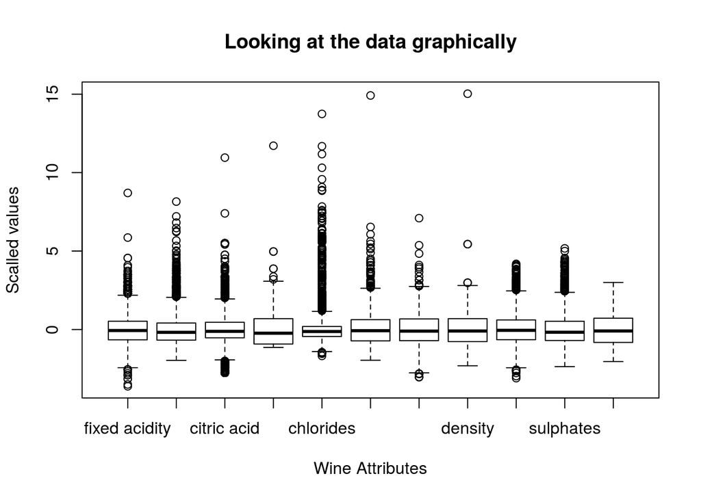

```r
boxplot(wine.scaled, main="Looking at the data graphically", xlab="Wine Attributes", ylab="Scalled values")
```

We can see from these box-plots that some attributes seem to have some clear outliers that would suggest erroneous data and not just natural extremes. As such, we can decide that it’s worth cleansing the data a little by removing these outliers from the dataset. For example, Alcohol on the most right column seesms to have very clear boundaries as we’d expect from wine; when that is compared with some other attributes, they seem to tell a different story: Chlorides seems to have a lot of values that are in the upper quartile, and a large distance etween min and max values but when you look it you can see there’s a gradient that suggests a normal distribution; in contrast to this, the columns Residual Sugar, Free Sulfur Dioxide and Density all seem to not only have relatively large min and max distances but there seem to be uppermost values that with nearest neighbour values that are a relatively large distance away.

Below are density line graphs to demonstrate the difference between attributes that don’t seem to have outliers compared to those that do.

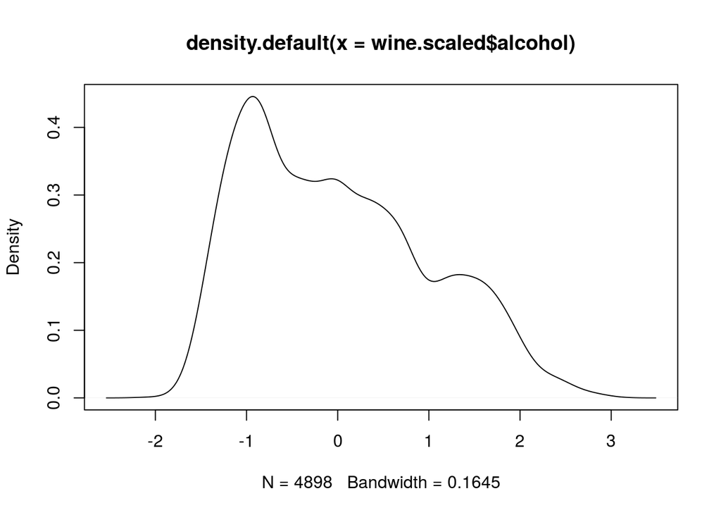

```r
plot(density(wine.scaled$`alcohol`))
```

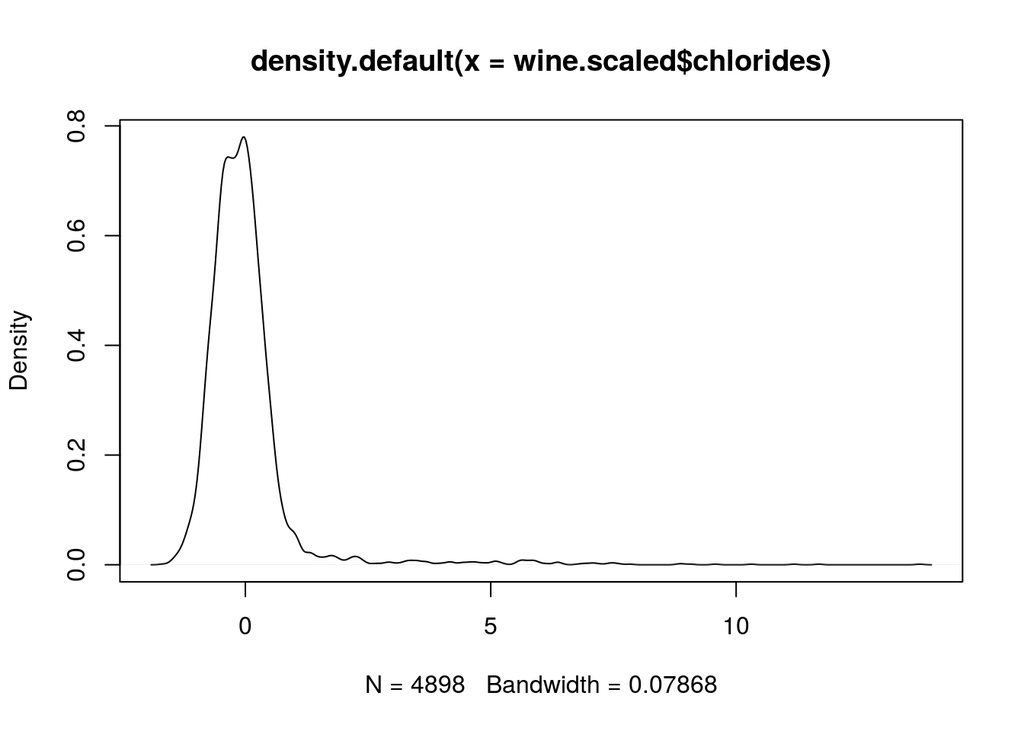

```r
plot(density(wine.scaled$`chlorides`))
```

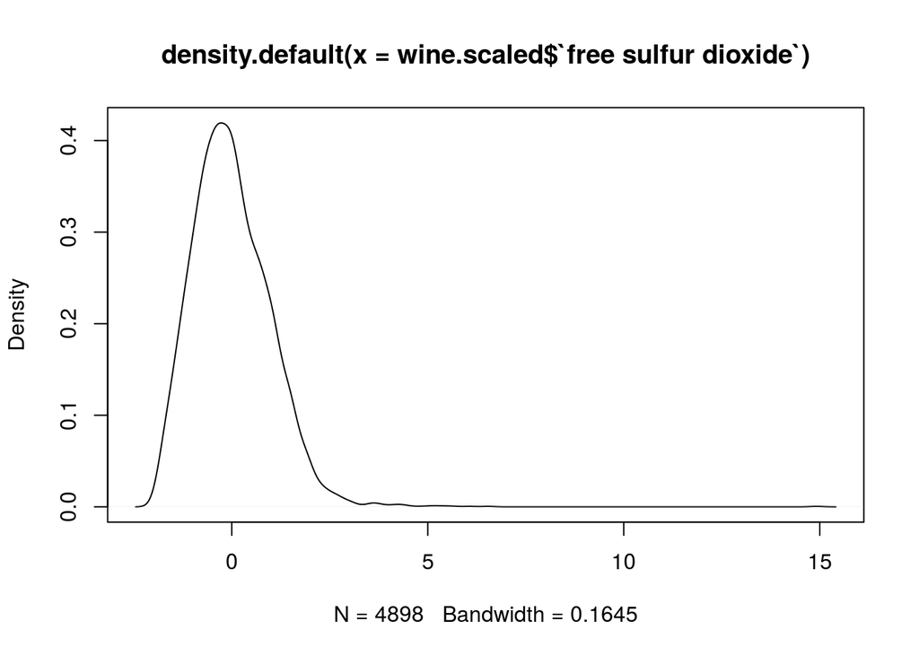

```r
plot(density(wine.scaled$`free sulfur dioxide`))
```

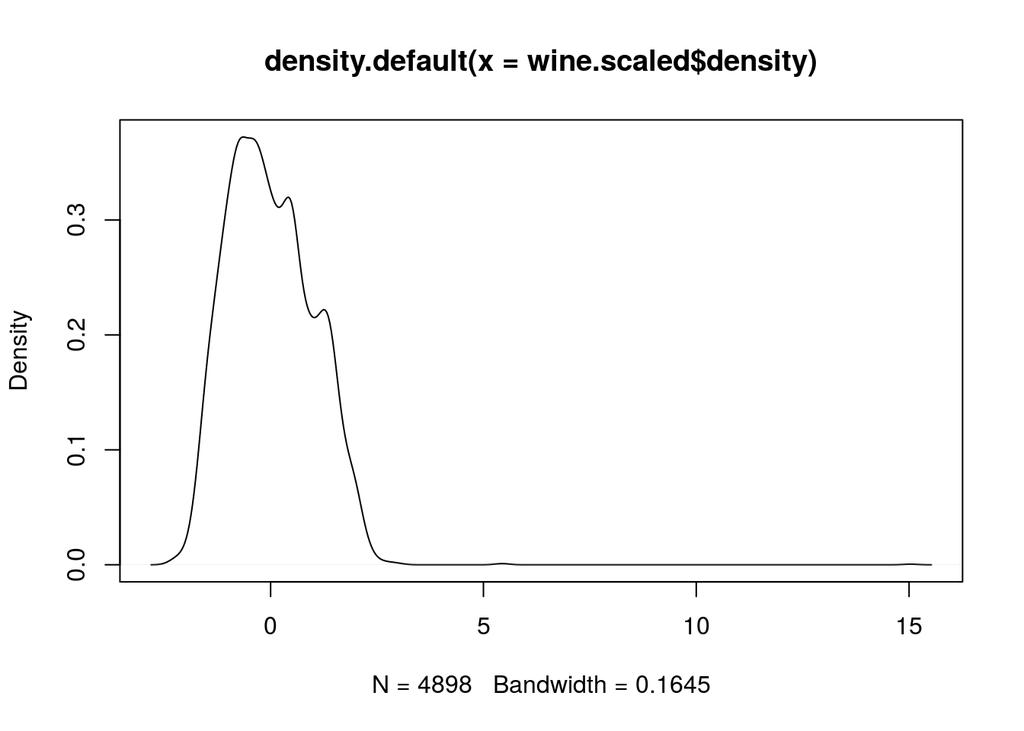

```r
plot(density(wine.scaled$`density`))
```

In order to work out which attributes should be considered to have valid outliers, I’ve gone with a heuristic approach, choosing to look at the distance between the uppermost outliers for each attribute and it’s nearest neighbour.

```r
#Create a list to populate with our tail neighbour distances
tail_deltas <- list()

for (attrib in wine.scaled) {
  #get the last two values
  data_tails <- tail(sort(attrib),2)
  #push the delta on to our list
  tail_deltas <- append(tail_deltas, diff(data_tails))
}

#We seem to be creating a vector of vectors to we need to flatten this (TODO: Fix if we have time!)
flattened_delta_list <- unlist(tail_deltas, recursive=FALSE)

#grab out attribute keys to include in our new table/frame
attributes <- names(wine.scaled)

#make a new dataframe from
dataframe <- data.frame(attributes = attributes, tail_neighbour_d=flattened_delta_list)

#get the order for the nearest neighbour starting with the greatest distance and descending
neighbout_order <- order(dataframe$tail_neighbour_d, decreasing=TRUE)

#now apply the order to the frame
dataframe[ neighbout_order, ]
```

```
##              attributes tail_neighbour_d
## 8               density        9.5890647
## 6   free sulfur dioxide        8.3788351
## 4        residual sugar        6.7428254
## 3           citric acid        3.5531375
## 1         fixed acidity        2.8440459
## 5             chlorides        2.0596881
## 7  total sulfur dioxide        1.7294905
## 2      volatile acidity        0.9425113
## 10            sulphates        0.1752452
## 11              alcohol        0.1218897
## 9                    pH        0.0662249
```

Given the findings, I think we can just consider the top five attributes in the above list as ones to cleanse for outliers. A lot of sources online warn against arbitrarily getting rid of outliers because it might be the case that valid information is being lost when what you really wnat to be account for is bad data.

To clarify, the attrbibutes to be processed are: - density  
- free sulfur dioxide  
- residual sugar  
- citric acid  
- fixed acidity

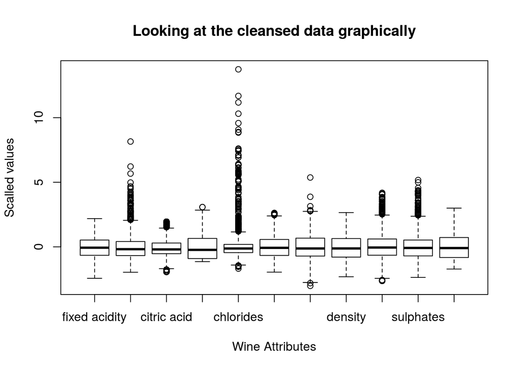

```r
wine.scaled_cleansed <- wine.scaled[ !(wine.scaled$density %in% boxplot(wine.scaled$density, plot=FALSE)$out), ]
wine.scaled_cleansed <- wine.scaled_cleansed[ !(wine.scaled_cleansed$`free sulfur dioxide` %in% boxplot(wine.scaled$`free sulfur dioxide`, plot=FALSE)$out), ]
wine.scaled_cleansed <- wine.scaled_cleansed[ !(wine.scaled_cleansed$`residual sugar` %in% boxplot(wine.scaled_cleansed$`residual sugar`, plot=FALSE)$out), ]
wine.scaled_cleansed <- wine.scaled_cleansed[ !(wine.scaled_cleansed$`citric acid` %in% boxplot(wine.scaled_cleansed$`citric acid`, plot=FALSE)$out), ]
wine.scaled_cleansed <- wine.scaled_cleansed[ !(wine.scaled_cleansed$`fixed acidity` %in% boxplot(wine.scaled_cleansed$`fixed acidity`, plot=FALSE)$out), ]

boxplot(wine.scaled_cleansed, main="Looking at the cleansed data graphically", xlab="Wine Attributes", ylab="Scalled values")
```

Now that the data looks a lot cleaner, it’s time to start working with the data to try and find the best clustering. To begin with, nbclust will be used to see if that produces anything useful.

```r
set.seed(123)

number_of_clusters <- NbClust(wine.scaled_cleansed,
                 min.nc=2, max.nc=15,
                 method="kmeans")
```

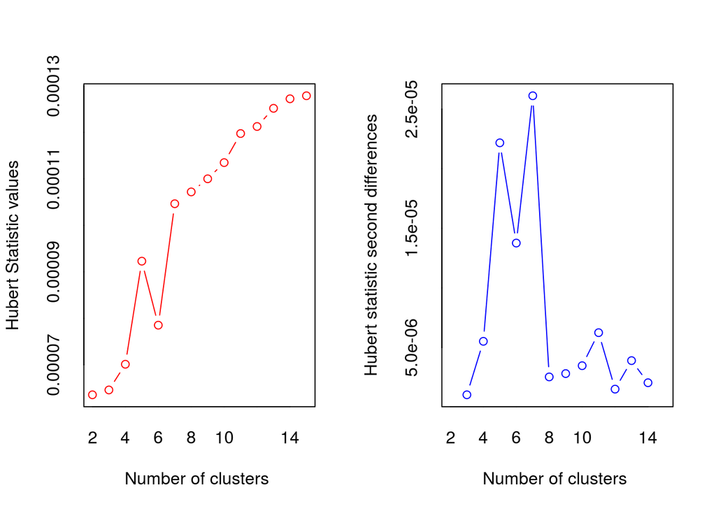

```
## *** : The Hubert index is a graphical method of determining the number of clusters.
##                 In the plot of Hubert index, we seek a significant knee that corresponds to a
##                 significant increase of the value of the measure i.e the significant peak in Hubert
##                 index second differences plot.
##
```

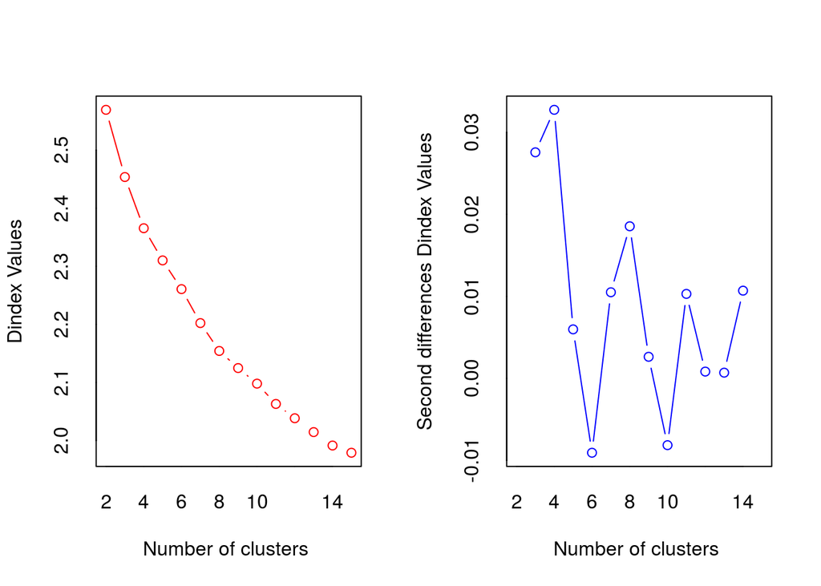

```
## *** : The D index is a graphical method of determining the number of clusters.
##                 In the plot of D index, we seek a significant knee (the significant peak in Dindex
##                 second differences plot) that corresponds to a significant increase of the value of
##                 the measure.
##
## * Among all indices:
## * 12 proposed 2 as the best number of clusters
## * 3 proposed 3 as the best number of clusters
## * 1 proposed 4 as the best number of clusters
## * 4 proposed 5 as the best number of clusters
## * 2 proposed 6 as the best number of clusters
## * 1 proposed 14 as the best number of clusters
## * 1 proposed 15 as the best number of clusters
##
##                    ***** Conclusion *****
##
## * According to the majority rule, the best number of clusters is  2
##
##
```

```r
table(number_of_clusters$Best.n[1,])
```

```
##
##  0  2  3  4  5  6 14 15
##  2 12  3  1  4  2  1  1
```